# Quality Control

- Show All Code
- Hide All Code
- View Source

Author

Harvard Chan Bioinformatics Core

Published

July 3, 2025

Template developed with materials from https://hbctraining.github.io/main/.

```r
# This set up the working directory to this file so all files can be found
library(rstudioapi)
setwd(fs::path_dir(getSourceEditorContext()$path))
# NOTE: This code will check version, this is our recommendation, it may work
# .      other versions
stopifnot(R.version$major >= 4) # requires R4
if (compareVersion(R.version$minor, "3.1") < 0) warning("We recommend >= R4.3.1")
stopifnot(compareVersion(as.character(BiocManager::version()), "3.18") >= 0)
```

This code is in this revision.

```r
# 1. set up factor_of_interest parameter from parameter above or manually
#    this is used to color plots, it needs to be part of the metadata
factor_of_interest <- params$factor_of_interest
genome <- params$genome
single_end <- params$single_end
# 2. Set input files in this file
source(params$params_file)
# 3. If you set up this file, project information will be printed below and
# .   it can be reused for other Rmd files.
source(params$project_file)
# 4. Load custom functions to load data from coldata/metrics/counts
source(params$functions_file)
```

# 1 Overview

```r
library(tidyverse)
library(janitor)
library(knitr)
library(rtracklayer)
library(DESeq2)
library(DEGreport)
library(ggrepel)
# library(RColorBrewer)
library(DT)
library(pheatmap)
library(RColorBrewer)
library(ggprism)
library(grafify)
ggplot2::theme_set(theme_prism(base_size = 12))
# https://grafify-vignettes.netlify.app/colour_palettes.html
# NOTE change colors here if you wish
scale_colour_discrete <- function(...) {
  scale_colour_manual(...,
    values = as.vector(grafify:::graf_palettes[["kelly"]])
  )
}
scale_fill_discrete <- function(...) {
  scale_fill_manual(...,
    values = as.vector(grafify:::graf_palettes[["kelly"]])
  )
}

opts_chunk[["set"]](
  cache = FALSE,
  cache.lazy = FALSE,
  dev = c("png", "pdf"),
  error = TRUE,
  highlight = TRUE,
  message = FALSE,
  prompt = FALSE,
  tidy = FALSE,
  warning = FALSE,
  fig.height = 4)
```

```r
sanitize_datatable <- function(df, ...) {
  # remove dashes which cause wrapping
  DT::datatable(df, ...,
    rownames = gsub("-", "_", rownames(df)),
    colnames = gsub("-", "_", colnames(df))
  )
}
```

# 2 Samples and metadata

```r
# This code will load from bcbio or nf-core folder
# TODO:  make sure to set numerator and denominator
coldata <- load_coldata(coldata_fn)
# Change this line to change the levels to the desired order.
# It will affect downstream colors in plots.
coldata[[factor_of_interest]] <- as.factor(coldata[[factor_of_interest]])
coldata$sample <- row.names(coldata)

counts <- load_counts(counts_fn)
counts <- counts[, colnames(counts) %in% coldata$sample]

metrics <- load_metrics(
  se_object, multiqc_data_dir,
  gtf_fn, counts, single_end
) %>%
  left_join(coldata, by = c("sample")) %>%
  as.data.frame()
metrics <- subset(metrics, metrics$sample %in% coldata$sample)
# TODO: change order as needed
order <- unique(metrics[["sample"]])
rownames(metrics) <- metrics$sample
# if the names don't match in order or string check files names and coldata information
counts <- counts[, rownames(metrics)]
coldata <- coldata[rownames(metrics), ]
stopifnot(all(names(counts) == rownames(metrics)))
```

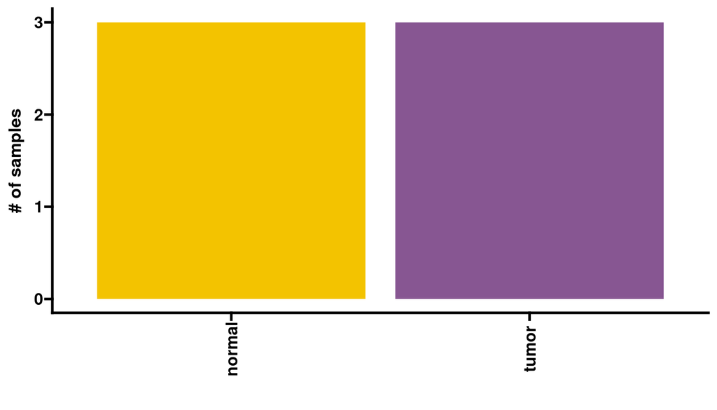

```r
meta_df <- coldata
ggplot(meta_df, aes(.data[[factor_of_interest]],
  fill = .data[[factor_of_interest]]
)) +
  geom_bar() +
  ylab("") +
  xlab("") +
  ylab("# of samples") +
  theme(
    axis.text.x = element_text(angle = 90, vjust = 0.5),
    legend.position = "none"
  )
```

```r
meta_sm <- meta_df %>%
  as.data.frame()

meta_sm %>% sanitize_datatable()
```

|  | sample | sample_type | description |
| --- | --- | --- | --- |
| SRX22997881 | SRX22997881 | tumor | SRX22997881 |
| SRX22997882 | SRX22997882 | normal | SRX22997882 |
| SRX22997883 | SRX22997883 | tumor | SRX22997883 |
| SRX22997884 | SRX22997884 | normal | SRX22997884 |
| SRX22997885 | SRX22997885 | tumor | SRX22997885 |
| SRX22997886 | SRX22997886 | normal | SRX22997886 |

# 3 Read metrics

**Total reads**

Here, we want to see consistency and a minimum of 20 million reads (the grey line).

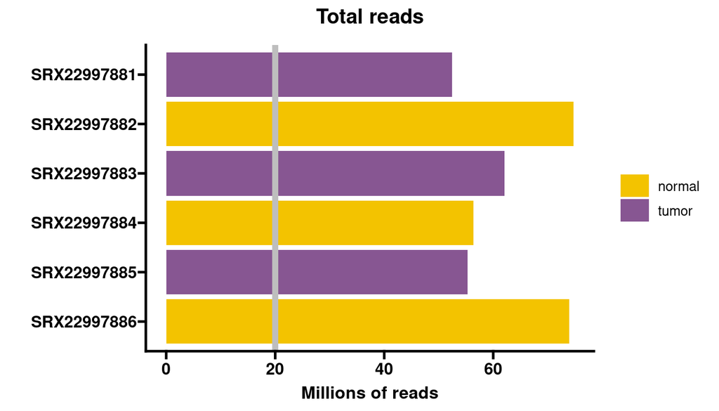

```r
metrics %>%
  ggplot(aes(
    x = factor(sample, level = order),
    y = total_reads, # if total reads are not already in millions, divide by 10000000 here
    fill = .data[[factor_of_interest]]
  )) +
  geom_bar(stat = "identity") +
  coord_flip() +
  scale_y_continuous(name = "Millions of reads") +
  scale_x_discrete(limits = rev) +
  xlab("") +
  ggtitle("Total reads") +
  geom_hline(yintercept = 20, color = "grey", linewidth = 2)
```

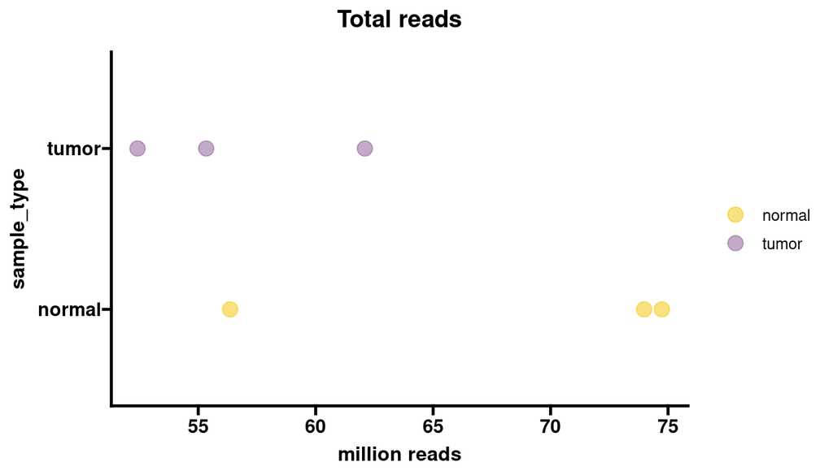

```r
metrics %>%
  ggplot(aes(
    x = .data[[factor_of_interest]],
    y = total_reads,
    color = .data[[factor_of_interest]]
  )) +
  geom_point(alpha = 0.5, size = 4) +
  coord_flip() +
  scale_y_continuous(name = "million reads") +
  ggtitle("Total reads")
```

```r
# get min percent mapped reads for reference
min_pct_mapped <- round(min(metrics$mapped_reads / metrics$total_reads) * 100, 1)
max_pct_mapped <- round(max(metrics$mapped_reads / metrics$total_reads) * 100, 1)
```

**Mapping rate**

The genomic mapping rate represents the percentage of reads mapping to the reference genome. We want to see consistent mapping rates between samples and over 70% mapping (the grey line). These samples have mapping rates: 97.3% - 98.1 %.

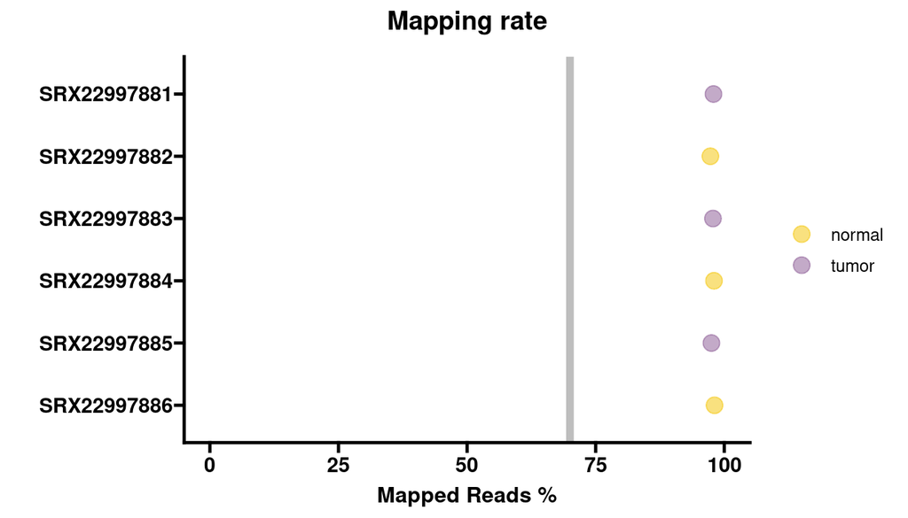

```r
metrics$mapped_reads_pct <- round(metrics$mapped_reads / metrics$total_reads * 100, 1)
metrics %>%
  ggplot(aes(
    x = factor(sample, level = order),
    y = mapped_reads_pct,
    color = .data[[factor_of_interest]]
  )) +
  geom_point(alpha = 0.5, size = 4) +
  coord_flip() +
  ylab("Mapped Reads %") +
  scale_x_discrete(limits = rev) +
  ylim(0, 100) +
  ggtitle("Mapping rate") +
  xlab("") +
  geom_hline(yintercept = 70, color = "grey", linewidth = 2)
```

**Number of genes detected**

The number of genes represented in every sample is expected to be consistent and over 20K (grey line).

```r
genes_detected <- colSums(counts > 0) %>% enframe()
sample_names <- metrics[, c("sample"), drop = F]
genes_detected <- left_join(genes_detected, sample_names, by = c("name" = "sample"))
genes_detected <- genes_detected %>% group_by(name)
genes_detected <- summarise(genes_detected,
  n_genes = max(value)
)

metrics <- metrics %>%
  left_join(genes_detected, by = c("sample" = "name"))
```

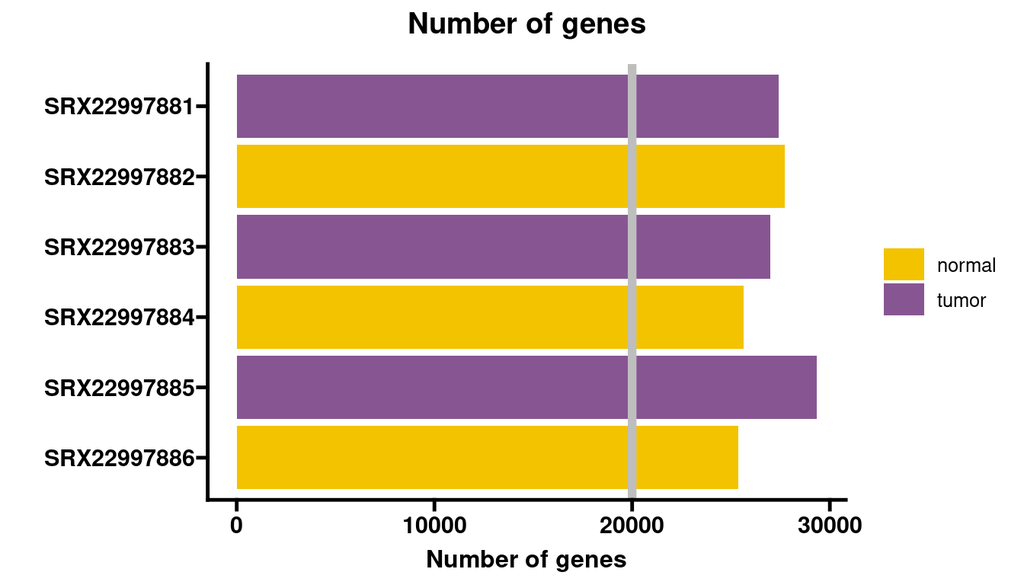

```r
ggplot(metrics, aes(
  x = factor(sample, level = order),
  y = n_genes, fill = .data[[factor_of_interest]]
)) +
  geom_bar(stat = "identity") +
  coord_flip() +
  scale_x_discrete(limits = rev) +
  ggtitle("Number of genes") +
  ylab("Number of genes") +
  xlab("") +
  geom_hline(yintercept = 20000, color = "grey", linewidth = 2)
```

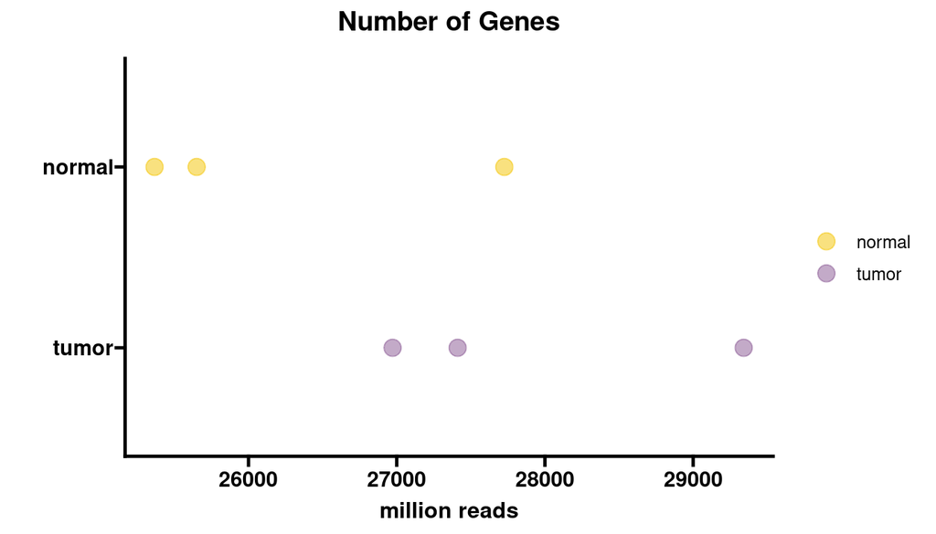

```r
metrics %>%
  ggplot(aes(
    x = .data[[factor_of_interest]],
    y = n_genes,
    color = .data[[factor_of_interest]]
  )) +
  geom_point(alpha = 0.5, size = 4) +
  coord_flip() +
  scale_x_discrete(limits = rev) +
  scale_y_continuous(name = "million reads") +
  xlab("") +
  ggtitle("Number of Genes")
```

**Gene detection saturation**

This plot shows how complex the samples are. We expect samples with more reads to detect more genes.

[figure not shown]

```r
metrics %>%
  ggplot(aes(
    x = total_reads / 1000000,
    y = n_genes,
    color = .data[[factor_of_interest]]
  )) +
  geom_point(alpha = 0.5, size = 4) +
  scale_x_log10() +
  ggtitle("Gene saturation") +
  ylab("Number of genes") +
  xlab("Millions of reads")
```

**Exonic mapping rate**

Here we are looking for consistency, and exonic mapping rates around or above 70% (grey line).

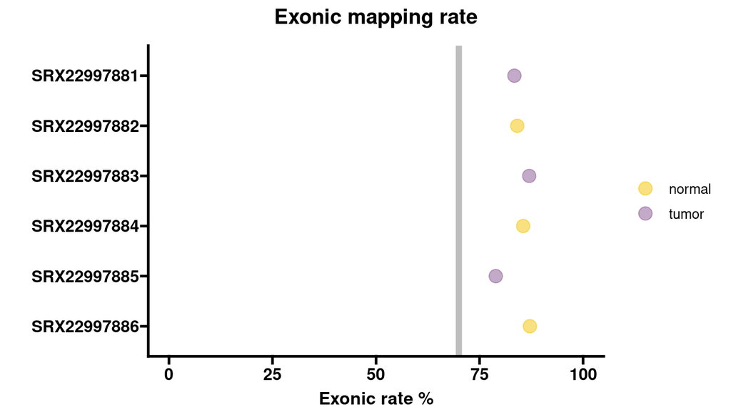

```r
metrics %>%
  ggplot(aes(
    x = factor(sample, level = order),
    y = exonic_rate * 100,
    color = .data[[factor_of_interest]]
  )) +
  geom_point(alpha = 0.5, size = 4) +
  ylab("Exonic rate %") +
  ggtitle("Exonic mapping rate") +
  scale_x_discrete(limits = rev) +
  coord_flip() +
  xlab("") +
  ylim(c(0, 100)) +
  geom_hline(yintercept = 70, color = "grey", linewidth = 2)
```

**Intronic mapping rate**

Here, we expect a low intronic mapping rate (≤ 15% - 20%). The grey line indicates 20%.

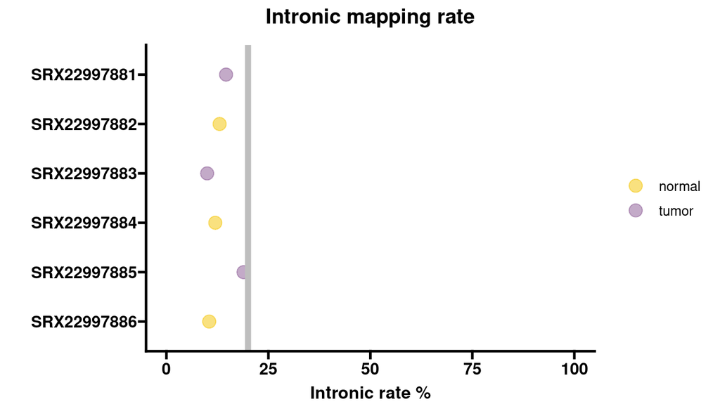

```r
metrics %>%
  ggplot(aes(
    x = factor(sample, level = order),
    y = intronic_rate * 100,
    color = .data[[factor_of_interest]]
  )) +
  geom_point(alpha = 0.5, size = 4) +
  ylab("Intronic rate %") +
  ggtitle("Intronic mapping rate") +
  scale_x_discrete(limits = rev) +
  coord_flip() +
  xlab("") +
  ylim(c(0, 100)) +
  geom_hline(yintercept = 20, color = "grey", linewidth = 2)
```

**Intergenic mapping rate**

Here, we expect a low intergenic mapping rate, which is true for all samples. The grey line indicates 15%

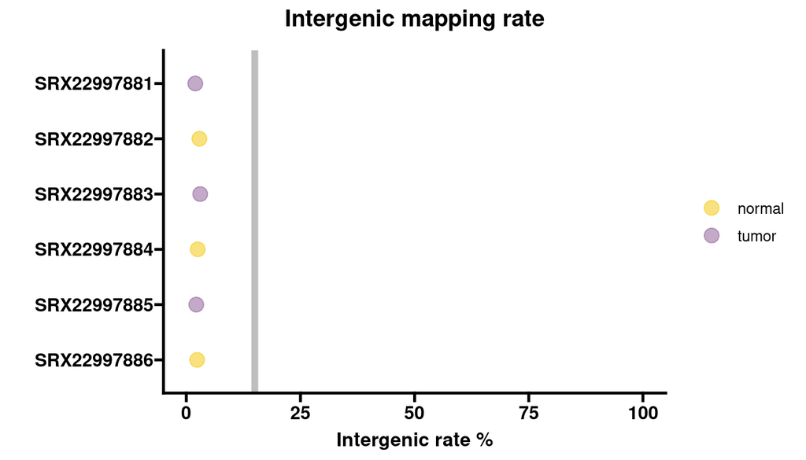

```r
metrics %>%
  ggplot(aes(
    x = factor(sample, level = order),
    y = intergenic_rate * 100,
    color = .data[[factor_of_interest]]
  )) +
  geom_point(alpha = 0.5, size = 4) +
  ylab("Intergenic rate %") +
  ggtitle("Intergenic mapping rate") +
  coord_flip() +
  xlab("") +
  scale_x_discrete(limits = rev) +
  ylim(c(0, 100)) +
  geom_hline(yintercept = 15, color = "grey", linewidth = 2)
```

**tRNA/rRNA mapping rate**

Samples should have a ribosomal RNA (rRNA) “contamination” rate below 10% (the grey line).

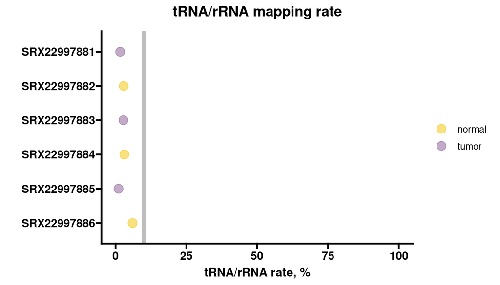

```r
rrna_ylim <- max(round(metrics$r_and_t_rna_rate * 100, 2)) + 10
metrics %>%
  ggplot(aes(
    x = factor(sample, level = order),
    y = r_and_t_rna_rate * 100,
    color = .data[[factor_of_interest]]
  )) +
  geom_point(alpha = 0.5, size = 4) +
  ylab("tRNA/rRNA rate, %") +
  ylim(0, rrna_ylim) +
  ggtitle("tRNA/rRNA mapping rate") +
  coord_flip() +
  scale_x_discrete(limits = rev) +
  ylim(c(0, 100)) +
  xlab("") +
  geom_hline(yintercept = 10, color = "grey", linewidth = 2)
```

**5’->3’ bias**

There should be little bias, i.e. the values should be close to 1, or at least consistent among samples

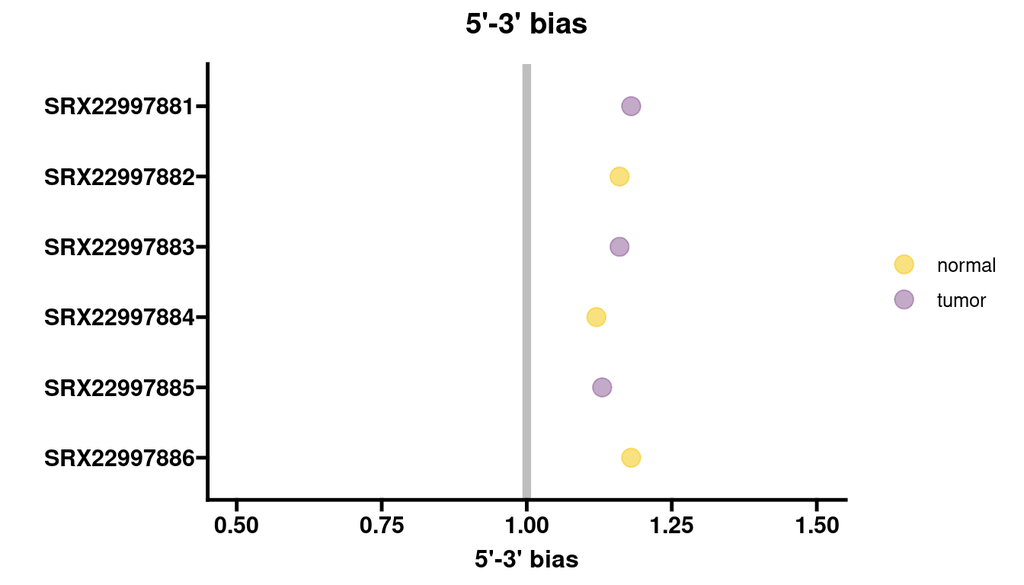

```r
metrics %>%
  ggplot(aes(
    x = factor(sample, level = order),
    y = x5_3_bias,
    color = .data[[factor_of_interest]]
  )) +
  geom_point(alpha = 0.5, size = 4) +
  ggtitle("5'-3' bias") +
  coord_flip() +
  scale_x_discrete(limits = rev) +
  ylim(c(0.5, 1.5)) +
  xlab("") +
  ylab("5'-3' bias") +
  geom_hline(yintercept = 1, color = "grey", linewidth = 2)
```

**Counts per gene - all genes**

We expect consistency in the box plots here between the samples, i.e. the distribution of counts across the genes is similar

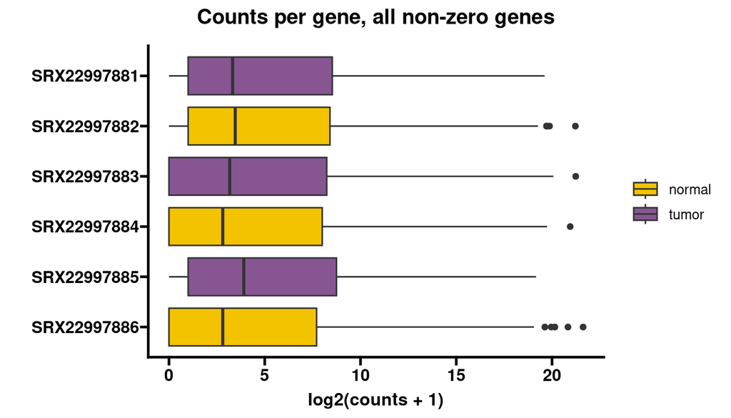

```r
metrics_small <- metrics %>% dplyr::select(sample, .data[[factor_of_interest]])
metrics_small <- left_join(sample_names, metrics_small)

counts_lng <-
  counts %>%
  as_tibble() %>%
  filter(rowSums(.) != 0) %>%
  gather(name, counts)

counts_lng <- left_join(counts_lng, metrics_small, by = c("name" = "sample"))

ggplot(counts_lng, aes(factor(name, level = order),
  log2(counts + 1),
  fill = .data[[factor_of_interest]]
)) +
  geom_boxplot() +
  scale_x_discrete(limits = rev) +
  coord_flip() +
  xlab("") +
  ggtitle("Counts per gene, all non-zero genes")
```

# 4 Sample similarity analysis

In this section, we look at how well the different groups in the dataset cluster with each other. Samples from the same group should ideally be clustering together. We use Principal Component Analysis (PCA).

## 4.1 Principal component analysis (PCA)

Principal Component Analysis (PCA) is a statistical technique used to simplify high-dimensional data by identifying patterns and reducing the number of variables. In the context of gene expression, PCA helps analyze large datasets containing information about the expression levels of thousands of genes across different samples (e.g., tissues, cells).

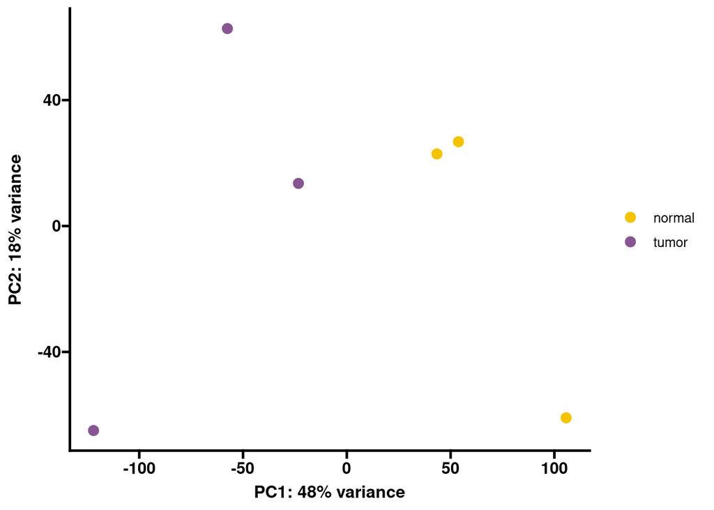

```r
vst <- vst(counts)

coldat_for_pca <- as.data.frame(metrics)
rownames(coldat_for_pca) <- coldat_for_pca$sample
coldat_for_pca <- coldat_for_pca[colnames(counts), ]
pca1 <- degPCA(vst, coldat_for_pca,
  condition = factor_of_interest, data = T
)[["plot"]]
pca2 <- degPCA(vst, coldat_for_pca,
  condition = factor_of_interest, data = T, pc1 = "PC3", pc2 = "PC4"
)[["plot"]]



pca1 + scale_color_grafify(palette = "kelly")
```

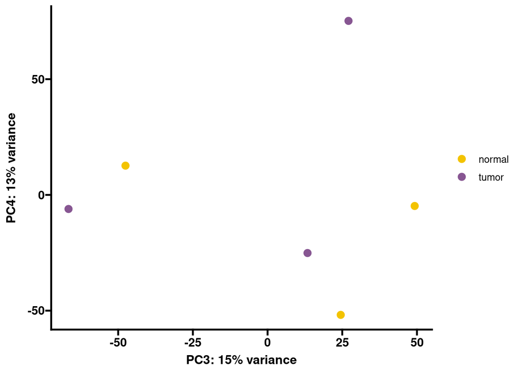

```r
pca2 + scale_color_grafify(palette = "kelly")
```

## 4.2 Hierarchical clustering

Inter-correlation analysis (ICA) is another way to look at how well samples cluster by plotting the correlation between the expression profiles of the samples.

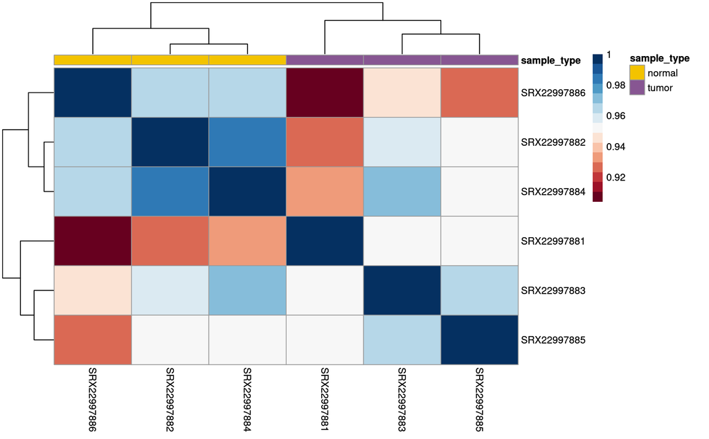

```r
vst_cor <- cor(vst)

colma <- coldata %>% as.data.frame()
rownames(colma) <- colma$sample
colma <- colma[rownames(vst_cor), ]
colma <- colma %>% dplyr::select(.data[[factor_of_interest]])
anno_colors <- lapply(colnames(colma), function(c) {
  l.col <- grafify:::graf_palettes[["kelly"]][1:length(unique(colma[[c]]))]
  names(l.col) <- levels(colma[[c]])
  l.col
})
names(anno_colors) <- colnames(colma)

p <- pheatmap(vst_cor,
  annotation = colma,
  annotation_colors = anno_colors,
  show_rownames = T,
  show_colnames = T,
  color = colorRampPalette(brewer.pal(11, "RdBu"))(15)
)
p
```